# RNA-Seq Data Introduction

Jineta Banerjee

08 September, 2020

# 1 Getting Started

The scope of this document is to inform participants:

- how to navigate the Synapse environment to access and work with the data files
- display the key features of the gene-expression (RNASeq) dataset
- introduce few general analyses steps of the data and their interpretation

At the end of this document, the participants would be able to download the data and understand various intricacies that exists in this given dataset. We encourage participants to visualize the dataset by faceting on different variables to get an accurate understanding of the dataset.

## 1.1 Loading Analytical Packages

Lets first load the R packages we need to query, download, and analyze the data that is stored on Synapse.

## 1.2 Logging in to Synapse

Please download the Synapse R client: [R](https://r-docs.synapse.org/) and refer to the necessary docs [synapser docs](https://r-docs.synapse.org/articles/synapser.html#connecting-to-synapse) to successfully log in to synapse and start using its various analytical tools.

```r
## The login credentials have been stored in .synapseConfig file in the home dir. If you dont have this setup, please make the file before trying to login.
synLogin()
```

```
## Welcome, Jineta Banerjee!
```

```r
set.seed('99999')  #set seed for reproducibility
```

## 1.3 Accessing or downloading data from Synapse

- Look up the SynID of the required file and then use the **synTableQuery** command to access the required data table.

```r
#### Download the individual data tables:
# 1. These are large files, so downloads will take a while, please be patient!
# 2. You will only be able to access the files to which you have been granted access. Please visit the Synapse hackathon page to fulfill the access requirements
cnf_data_resource <- synTableQuery("SELECT * FROM syn21222341")$asDataFrame()
synodos_nf2 <- synTableQuery("SELECT * FROM syn21520573")$asDataFrame()
synodos_nf1 <- synTableQuery("SELECT * FROM syn21520550")$asDataFrame()
jhu_biobank <- synTableQuery("SELECT * FROM syn20812185")$asDataFrame()
nf1_glioma <- synTableQuery("SELECT * FROM syn21521726")$asDataFrame()
pnf_cell_line <- synTableQuery("SELECT * FROM syn22351884")$asDataFrame()
```

[output not shown]

```r
## add darbro synodos NF1 data

all_rnaseq <- rbind(cnf_data_resource,
                    synodos_nf2,
                    synodos_nf1,
                    jhu_biobank,
                    nf1_glioma,
                    pnf_cell_line)
```

# 2 Exploring the data files

## 2.1 Structure of the file

Lets first take a brief look at the contents of the accessed file:

```r
# Clean up dataframe
all_rnaseq$sex[all_rnaseq$sex == "male"] <- "Male"
all_rnaseq$sex[all_rnaseq$sex == "female"] <- "Female"
colnames(all_rnaseq)[colnames(all_rnaseq)=="used"] <- "id"

#remove any rows that dont have valid synapse id associated with the data
all_rnaseq <- all_rnaseq %>%
  dplyr::filter(!is.na(id))

##Inspect the file
print("Dimensions of the file:")
```

```
## [1] "Dimensions of the file:"
```

```r
dim(all_rnaseq)
```

```
## [1] 2458888      28
```

```r
print("Contents of the file:")
```

```
## [1] "Contents of the file:"
```

```r
head(all_rnaseq)
```

|  | ROW_ID | ROW_VERSION | totalCounts | Symbol | path | zScore | specimenID | parent | individualID | assay | dataType | sex | consortium | study | diagnosis | tumorType | species | fundingAgency | resourceType | nf1Genotype | nf2Genotype | studyName | id | age | isCellLine | experimentalCondition | transplantationType | modelOf |
| --- | --- | --- | --- | --- | --- | --- | --- | --- | --- | --- | --- | --- | --- | --- | --- | --- | --- | --- | --- | --- | --- | --- | --- | --- | --- | --- | --- | --- |
| 1 | 1 | 1 | 136.993 | A1BG | patient10tumor1_quant.sf | -0.2268608 | patient10tumor1 | syn18407530 | patient10 | rnaSeq | geneExpression | Male | CTF Biobank | cNF Initial Data Release | Neurofibromatosis 1 | Cutaneous Neurofibroma | Human | CTF | experimentalData | -/- | unknown | Cutaneous Neurofibroma Data Resource | syn20430744 | NA | NA | NA | NA | NA |
| 2 | 2 | 1 | 168.454 | A1BG | patient10tumor2_quant.sf | -0.2488886 | patient10tumor2 | syn18407530 | patient10 | rnaSeq | geneExpression | Male | CTF Biobank | cNF Initial Data Release | Neurofibromatosis 1 | Cutaneous Neurofibroma | Human | CTF | experimentalData | -/- | unknown | Cutaneous Neurofibroma Data Resource | syn20430745 | NA | NA | NA | NA | NA |
| 3 | 3 | 1 | 115.456 | A1BG | patient10tumor3_quant.sf | -0.1156245 | patient10tumor3 | syn18407530 | patient10 | rnaSeq | geneExpression | Male | CTF Biobank | cNF Initial Data Release | Neurofibromatosis 1 | Cutaneous Neurofibroma | Human | CTF | experimentalData | -/- | unknown | Cutaneous Neurofibroma Data Resource | syn20430746 | NA | NA | NA | NA | NA |
| 4 | 4 | 1 | 500.304 | A1BG | patient11tumor1_quant.sf | -0.1847285 | patient11tumor1 | syn18407530 | patient11 | rnaSeq | geneExpression | Female | CTF Biobank | cNF Initial Data Release | Neurofibromatosis 1 | Cutaneous Neurofibroma | Human | CTF | experimentalData | -/- | unknown | Cutaneous Neurofibroma Data Resource | syn20430747 | NA | NA | NA | NA | NA |
| 5 | 5 | 1 | 380.698 | A1BG | patient11tumor14_quant.sf | -0.2291648 | patient11tumor14 | syn18407530 | patient11 | rnaSeq | geneExpression | Female | CTF Biobank | cNF Initial Data Release | Neurofibromatosis 1 | Cutaneous Neurofibroma | Human | CTF | experimentalData | -/- | unknown | Cutaneous Neurofibroma Data Resource | syn20430748 | NA | NA | NA | NA | NA |
| 6 | 6 | 1 | 71.568 | A1BG | patient11tumor3_quant.sf | -0.1448767 | patient11tumor3 | syn18407530 | patient11 | rnaSeq | geneExpression | Female | CTF Biobank | cNF Initial Data Release | Neurofibromatosis 1 | Cutaneous Neurofibroma | Human | CTF | experimentalData | -/- | unknown | Cutaneous Neurofibroma Data Resource | syn20430749 | NA | NA | NA | NA | NA |

The following table contains detailed descriptions of the metadata variables included in the data file:

[output not shown]

## 2.2 Metadata

The metadata in a healthcare study includes descriptions of the specimens, and the details of the studies they originated from. We can explore the metadata by visualizing various aspects of it to get a sense of the data contained within our dataset and put it in context of the disease and patients.

For example, we can visualize the data distribution according to sex.

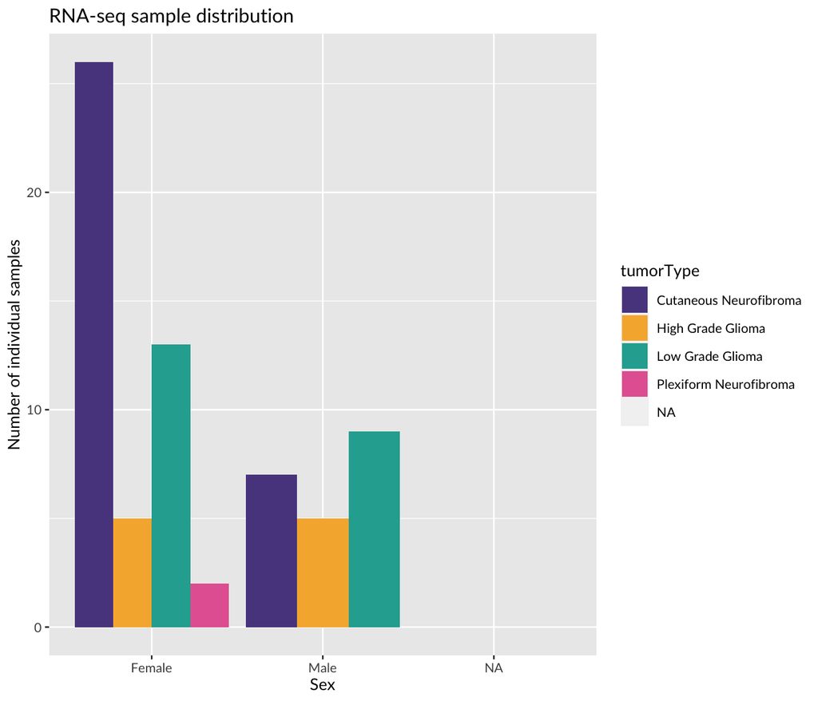

```r
#Plot Metadata
ggplot(all_rnaseq %>%
         dplyr::select(specimenID,tumorType,sex) %>%
         unique(),
       aes(x=sex))+
    geom_bar(aes(x=sex,fill=tumorType),position='dodge')+
  xlab("Sex") +
  ylab("Number of individual samples") +
  ggtitle('RNA-seq sample distribution')+
  scale_fill_sage_d() +
  theme_sage(base_size = 10)
```

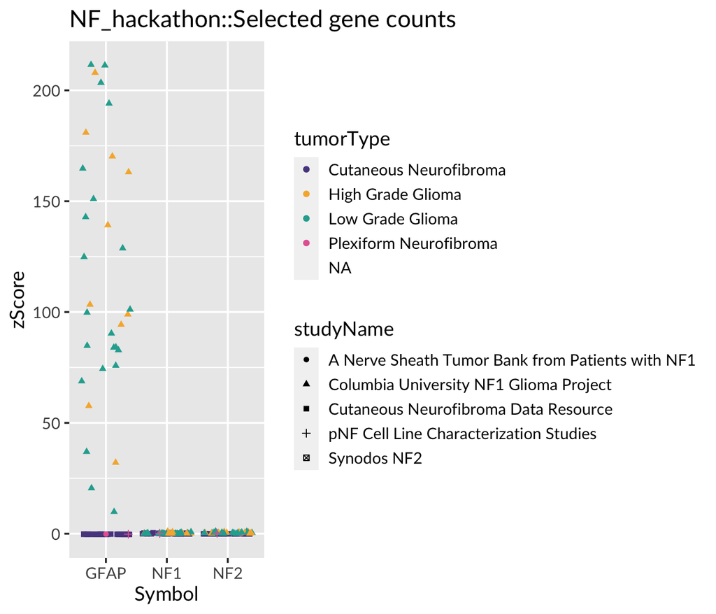

```r
#Plot genes with metadata
analyzeMetdataWithGenes<-function(datafile,prefix, gene_a, ...){
  #look at some marker genes using normalized zScore
  ggplot(subset(datafile,Symbol%in%c(gene_a, ...)))+
    geom_jitter(aes(x=Symbol,
                    y=zScore,
                    shape=studyName,
                    col=tumorType))+
    ggtitle(paste(prefix,'Selected gene counts', sep = '::'))+
    scale_color_sage_d() +
    theme_sage()
}
analyzeMetdataWithGenes(all_rnaseq, "NF_hackathon", "NF1", "NF2", "GFAP")
```

## 2.3 Visualizing expression of specific genes in different tumor types

We can further visualize the expression of specific genes in different tumorTypes to investigate the possible contribution of that gene to the progression of various tumorTypes.For example lets plot the expression levels of the genes *GFAP* *(astrocyte-specific marker gene)*, *NF1* *(neurofibromin 1 gene)*, *NF2* *(neurofibromin 2 gene)* in different tumortypes. Since our datasets contain human data, make sure to include gene names specific to humans.

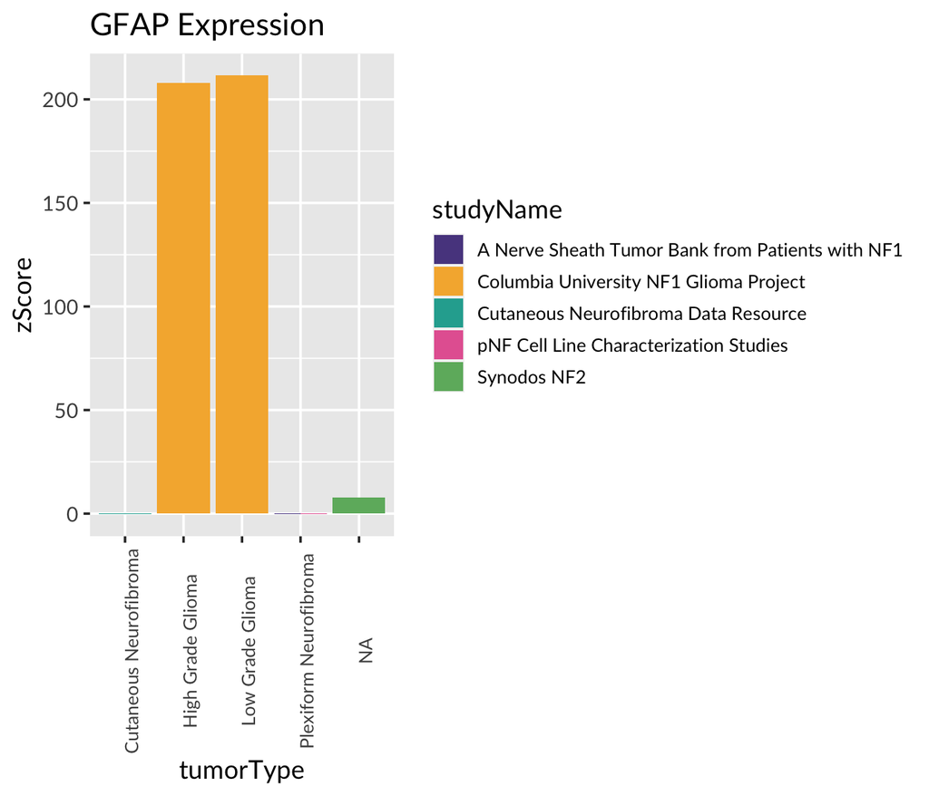

```r
##barplot

singleGeneBarplot<-function(datafile,gene){
  ggplot(subset(datafile,Symbol==gene))+
    geom_bar(aes(x=tumorType,
                 y=zScore,
                 fill=studyName),
             stat='identity',position='dodge')+
    ggtitle(paste(gene,'Expression'))+
    ggpubr::rotate_x_text()+
    scale_fill_sage_d() +
    theme_sage()+
    theme(axis.text.x  = element_text(size=10, angle = 90),
          legend.text = element_text(size=10),
              legend.position="right")
}

singleGeneBarplot(all_rnaseq,'GFAP')
```

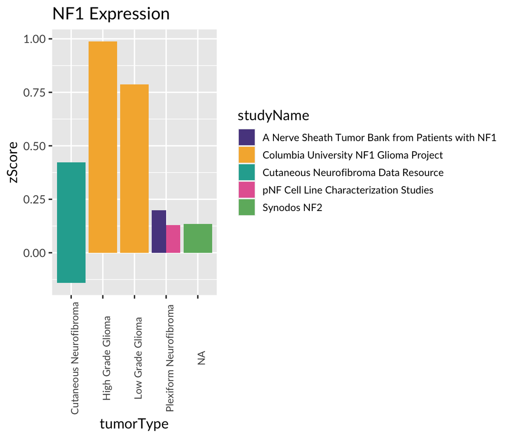

```r
singleGeneBarplot(all_rnaseq,'NF1')
```

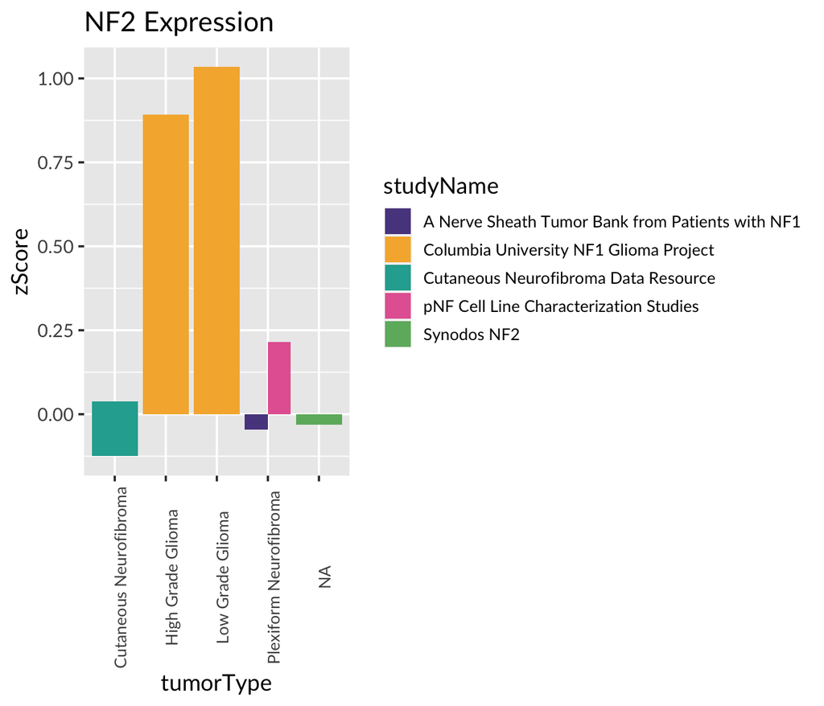

```r
singleGeneBarplot(all_rnaseq,'NF2')
```

# 3 Data Analysis

## 3.1 Dimensionality Reduction

To explore the data and find meaningful differences between samples, we first perform some dimensionality reduction using principal component analysis. We can then look at the genes that are top contributors to the first few principal components.

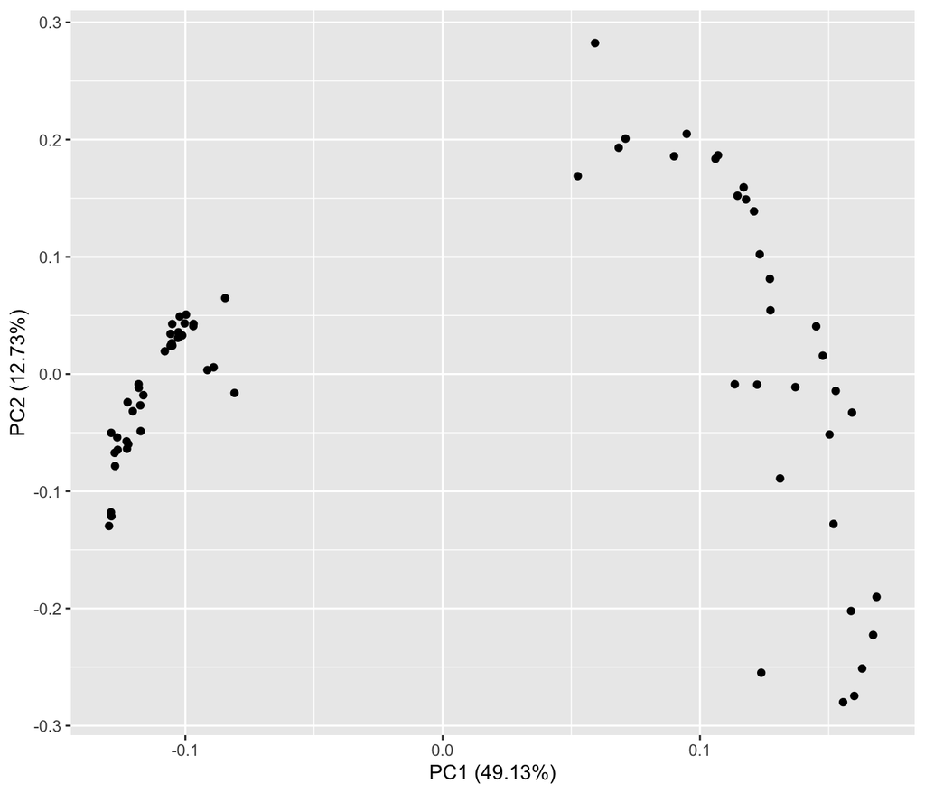

```r
###PCA plots
#all_rnaseq$specimenID <- as.factor(all_rnaseq$specimenID)

doPcaPlots<-function(datafile, env){
  #create matrix
  combined.mat=reshape2::acast(datafile,Symbol~specimenID,value.var="zScore", fun.aggregate = mean)

  #then remove missing
  missing=which(apply(combined.mat,1,function(x) any(is.na(x))))
  combined.mat=combined.mat[-missing,]

  ###PCA
  library(ggfortify)
  env$tab <- autoplot(prcomp(t(combined.mat)))

  ###Look at genes contributing to PCs
  loads=prcomp(combined.mat)$x

  genes1=rownames(combined.mat)[rev(order(loads[,1]))[1:25]]
  #now take those loadings from pc1
  env$tab1 <- ggplot(subset(datafile,Symbol%in%genes1[1:5]))+
                    geom_jitter(aes(x=Symbol,
                                    y=zScore,
                                    col=tumorType,
                                    shape=studyName),
                                width =0.1, size=2, height = 0.1)+
                    ggtitle('Selected gene counts from PC1')+
    scale_color_sage_d() +
    theme_sage()+
    theme(axis.text.x  = element_text(size=10, angle = 45),
          legend.text = element_text(size=10),
              legend.position="right")

  genes2=rownames(combined.mat)[rev(order(loads[,2]))[1:25]]
  #now take those loadings from pc2
  env$tab2 <- ggplot(subset(datafile,Symbol%in%genes2[1:5]))+
              geom_jitter(aes(x=Symbol,
                              y=zScore,
                              col=tumorType,
                              shape=studyName),
                          width =0.1, size=2, height = 0.1)+
              ggtitle('Selected gene counts from PC2')+
    scale_color_sage_d() +
    theme_sage()+
    theme(axis.text.x  = element_text(size=10, angle = 45),
          legend.text = element_text(size=10),
              legend.position="right")
}

myEnv <- new.env()
doPcaPlots(all_rnaseq, myEnv)
myEnv$tab
```

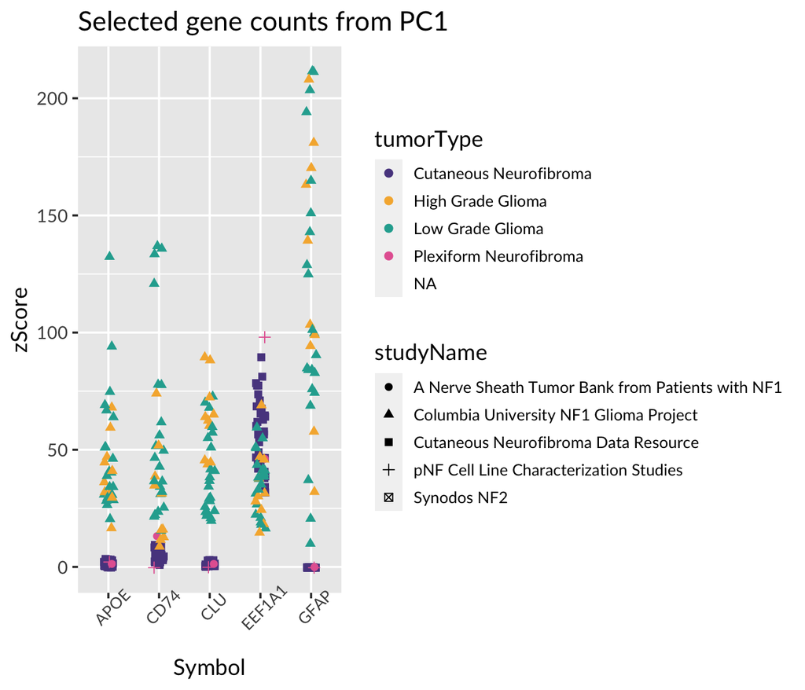

```r
myEnv$tab1
```

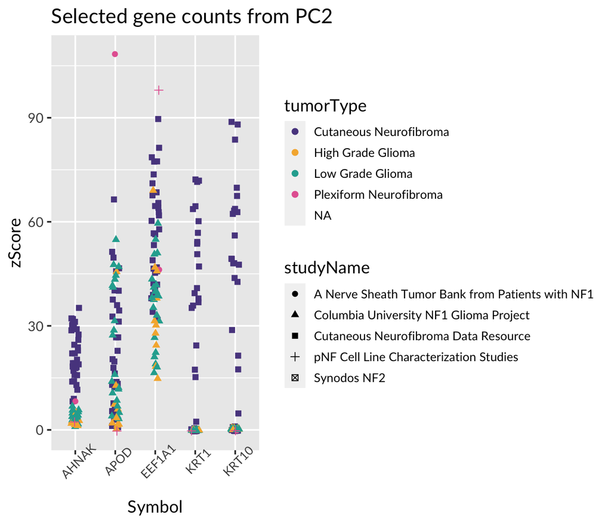

```r
myEnv$tab2
```

Here we notice that the dataset seems to have two distinct clusters.

## 3.2 Differences in gene expression between conditions

One of the fundamental questions of interest is whether expression of a gene of interest is different in various conditions. For example, is the expression of our favorite genes different in males vs females. To answer this question we can compare the *normalized* expression levels of our genes of interest between males and females and visualize the fold change in expression between the sexes in the following boxplot. Please note that for comparision of gene expression, we generally use normalized log counts instead of raw counts.

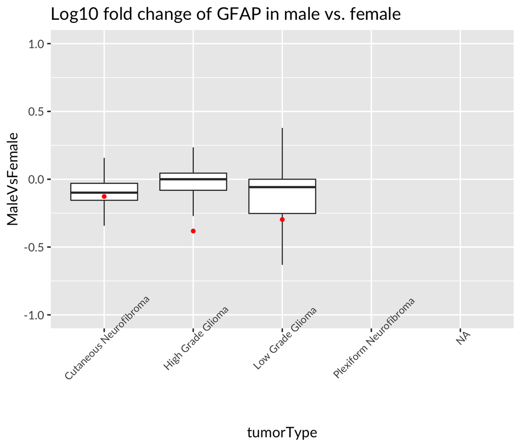

```r
#take log of counts
with.log=all_rnaseq%>%mutate(logCounts=log10(totalCounts+0.0001))

##now take mean across sex,tumor type and gene
diffexdata <- with.log%>%
  group_by(tumorType,Symbol,sex)%>%
  mutate(mcounts=mean(logCounts))%>%
  dplyr::select(tumorType,sex,Symbol,mcounts)%>%
  unique()%>%spread(sex,mcounts)%>%
  mutate(MaleVsFemale=Male-Female)

##Plot fold change
diffExBoxplot<-function(diff_file,gene){
  ggplot(diff_file)+
    geom_boxplot(aes(x=tumorType,
                     y=MaleVsFemale),
                 outlier.color=NA)+
    ylim(c(-1,1))+
    ggpubr::rotate_x_text()+
    geom_point(data=subset(diff_file,
                           Symbol==gene),mapping=aes(x=tumorType,
                                                               y=MaleVsFemale),color='red')+
    ggtitle(paste('Log10 fold change of',gene,'in male vs. female'))+
    scale_color_sage_d() +
    theme_sage()+
    theme(axis.text.x  = element_text(size=10, angle = 45),
          legend.text = element_text(size=10),
              legend.position="right")
}

diffExBoxplot(diffexdata,'GFAP')
```

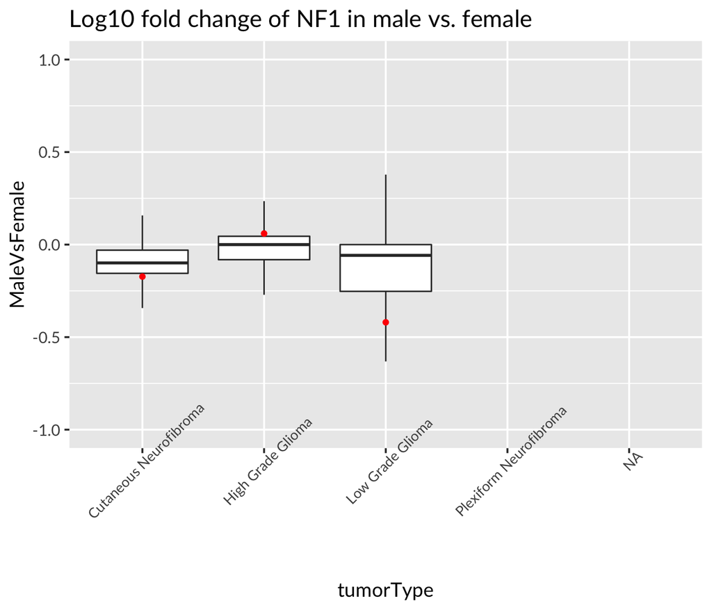

```r
diffExBoxplot(diffexdata,'NF1')
```

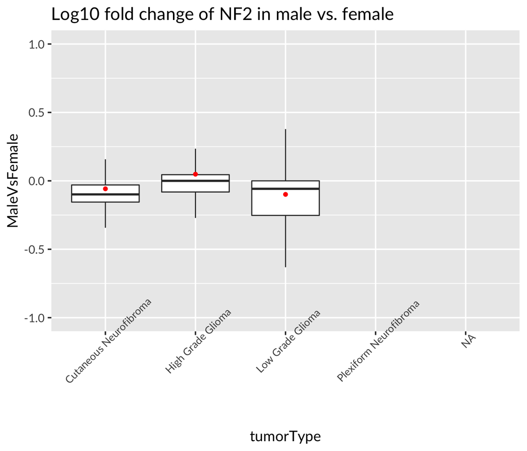

```r
diffExBoxplot(diffexdata,'NF2')
```

## 3.3 Gene Ontology Analysis

While thousands of genes can change expression levels, the biological relevance of such changes are estimated by investigating the changes in biological processes in which the genes are involved. To get a sense of which biological processes may be linked to our list of upregulated or downregulated genes, we may perform a *Gene Ontology (GO) Enrichment Analysis* and visualize the most common processes relevant to our analysis. In the following plot, the biological processes enriched in our list of upregulated genes (left, G1) and downregulated genes (right, G2) for Low Grade Glioma is visualized in the form of a word cloud. The most significantly enriched term is on the top. These terms can give us subtle indications as to which cellular signaling pathways or gene regulatory networks may be most interesting in our follow-up analyses.

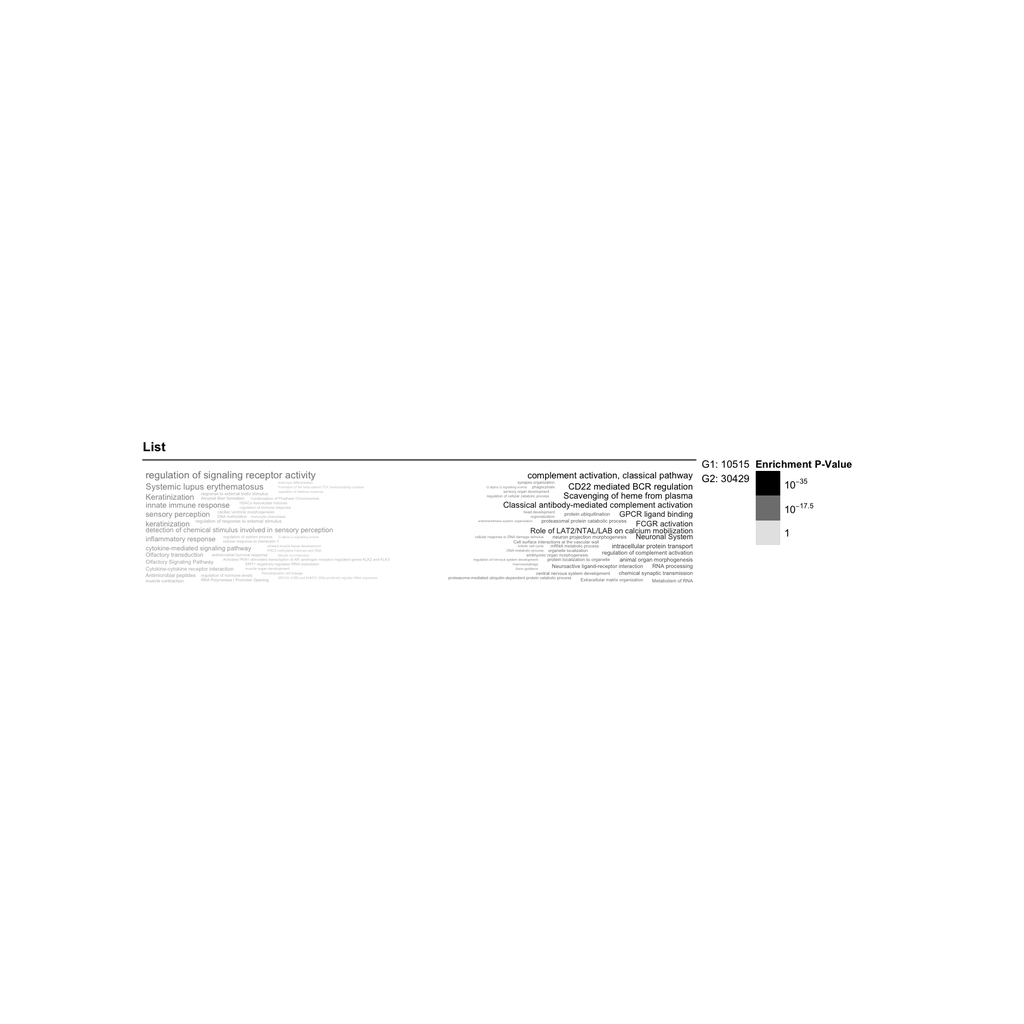

```r
#Make gene lists
DEG_genelist <- diffexdata[order(-diffexdata$MaleVsFemale),]
#sorted upregulated gene
gene_list_up <- subset(DEG_genelist, MaleVsFemale > 0 & tumorType == "Low Grade Glioma")
#sorted downregulated genes
gene_list_down <- subset(DEG_genelist, MaleVsFemale < 0 & tumorType == "Low Grade Glioma")
gene_list_down <- gene_list_down[order(gene_list_down$MaleVsFemale),]

#Make list of gene_lists (upreg genes and downreg genes)
gene_list = list(List = list(gene_list_up$Symbol, gene_list_down$Symbol))

#Make Wordcloud
gosummaries_object <- gosummaries(x = gene_list,
                                  organism = "hsapiens",
                                  go_branches = c("BP","keg", "rea"),
                                  min_set_size = 50,
                                  max_set_size = 1000,
                                  max_signif = 40,
                                  ordered_query = TRUE,
                                  hier_filtering = "moderate",
                                  wc_algorithm = "top",
                                  wordcloud_legend_title = NULL,
                                  correction_method = "fdr",
                                  domain_size = "annotated")

#Plot wordcloud
plot(gosummaries_object,
     components = 1:min(10, length(gosummaries_object)),
     panel_height = 0,
     panel_width = 30,
     fontsize = 9,
     term_length = 100,
     wordcloud_colors = c("grey90", "grey50", "black"),
     wordcloud_legend_title = "Enrichment P-Value")
```

## 3.4 Pathway Analysis

Generally disease conditions can change a *group of genes* ( *gene-sets* ) simultaneously, thus affecting one or more cellular signaling pathways and gene regulatory networks. Changes in *gene-sets* can be visualized to get an idea about how cellular signaling pathways may be affected by the disease condition.

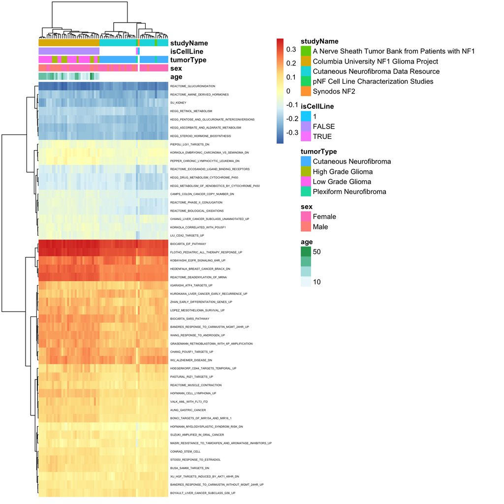

```r
mat<-reshape2::acast(all_rnaseq,Symbol~specimenID,value.var='zScore',fun.aggregate = mean)
#missing<-which(apply(mat,1,function(x) any(is.na(x))))
#mat<-mat[-missing,]
data("c2BroadSets")

#get mapping from enst to hgnc
mart = biomaRt::useMart("ensembl", dataset="hsapiens_gene_ensembl")
my_chr <- c(1:22,'X','Y')
map <- getBM(attributes=c("entrezgene_id","hgnc_symbol"),mart=mart,filters='chromosome_name',values=my_chr)

entrez<-map[match(rownames(mat),map[,2]),1]
mat<-mat[which(!is.na(entrez)),]
rownames(mat)<-entrez[!is.na(entrez)]

# override parallel::detectCores in case it fails to prevent gsva from failing
requireNamespace('parallel')
if (is.na(parallel::detectCores())) {
  my.detectCores = function() {
    return(1)
  }
  assignInNamespace("detectCores", my.detectCores, ns="parallel", envir=as.environment("package:parallel"))
}

res=gsva(mat,method='ssgsea',gset.idx.list=c2BroadSets)

vars<-apply(res,1,var)
annotes=all_rnaseq%>%dplyr::select(specimenID,age,sex,tumorType,isCellLine,studyName)%>%unique
rownames(annotes)<-annotes$specimenID

pheatmap(res[names(sort(vars)[1:50]),],
                       labels_col=rep("",ncol(res)),
                       fontsize_row = 4,
                       clustering_method = 'ward.D2',
                       annotation_col = dplyr::select(annotes,-specimenID),
                       width = 16,
                       height = 8)
```

```r
print(" First look at the GSVA results : ")
res[1:5,1:5]
```

[output not shown]